# Multinomial Logistic Regression Practical

Start by loading the `iris` dataset. You can go through the code much as you would in a regular R script.

```r
# Look at data
summary(iris)
```

```
  Sepal.Length    Sepal.Width     Petal.Length    Petal.Width          Species
 Min.   :4.300   Min.   :2.000   Min.   :1.000   Min.   :0.100   setosa    :50
 1st Qu.:5.100   1st Qu.:2.800   1st Qu.:1.600   1st Qu.:0.300   versicolor:50
 Median :5.800   Median :3.000   Median :4.350   Median :1.300   virginica :50
 Mean   :5.843   Mean   :3.057   Mean   :3.758   Mean   :1.199
 3rd Qu.:6.400   3rd Qu.:3.300   3rd Qu.:5.100   3rd Qu.:1.800
 Max.   :7.900   Max.   :4.400   Max.   :6.900   Max.   :2.500
```

## Part I: complete linear separation

We will start with a very naive approach. Without looking at the data, we try to predict whether the species is Setosa or not.

```r
# Run glm model
binmodel <- glm(Species ~ ., data=iris, family=binomial(link="logit"))
```

```
glm.fit: algorithm did not convergeglm.fit: fitted probabilities numerically 0 or 1 occurred
```

**Q. What does the warning message mean?**

(Hint: look at the summary of the model. What do you notice?)

```r
summary(binmodel)
```

[output not shown]

Let’s plot the data

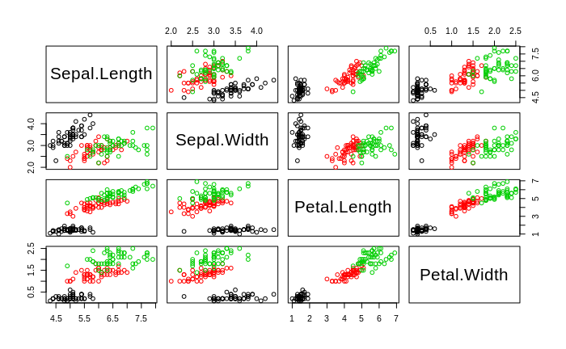

**Q. What do we conclude about this data?**

To further understand the problem of perfect separation, lets look at the data in a scatterplot. We cannot plot four dimensions, but perhaps three dimensions is enough?

```r
library(plotly)
library(ggplot2)
p <- plot_ly(iris, x = ~Sepal.Length, y = ~Petal.Length, z = ~Petal.Width,
             color = ~Species, colors = c('red', 'blue', 'green')) %>%
  add_markers() %>%
  layout(scene = list(xaxis = list(title = 'Sepal length'),
                      yaxis = list(title = 'Petal length'),
                      zaxis = list(title = 'Petal width')))
plotly_build(p)
```

[output not shown]

Another possibility is to compute the principal components of the data and to plot the first two components.

```r
prc <- princomp(iris[,1:4])
prc <- prc$scores

# Make a new dataset
prcdata <- data.frame("component1" = prc[,1],
                      "component2" = prc[,2],
                      "species" = iris[,5])

ggplot(prcdata, aes(x=component1, y=component2, color=species)) +
  geom_point() +
  theme_bw()
```

[output not shown]

**Q. for which research question is perfect separation an issue? Is it an issue if we want to make inferences or if we want to predict?**

(Hint: try to separate the algorithm from statistical theory. Which one is impacted by perfect separation of variables?)

## Part II: Multinomial logistic regression & making inferences

## Part III: Multinomial logistic regression for classification

We will be using a ‘naive’ model:

- model all three classes separately (as binaries). So we are running K models for K classes.
- we then compare the probabilities for each model and choose the ‘most likely’ one e.g. the class which has the highest probability.

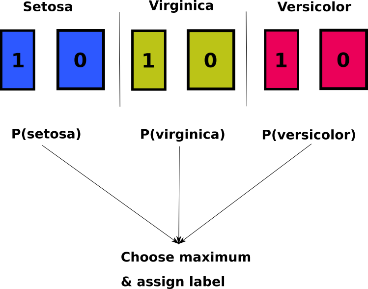

**Q. What is the research question?**

**Q. What do we want from the classifier? i.e. what are we trying to optimize**

The outcomes should look ‘likely’ given the data. So a point that is classified as class 1 but has a low probability of being selected as such gets penalized by the log-likelihood. As an aside, the use of the log function is a computational choice: by the rules of logarithms, products can be summed instead of multiplied when we take the log.

Now we perform multi-class classification. First, think about what a ‘naive’ model would do given K classes? Would it:

- guess randomly?
- choose the class with the maximum number of subjects?
- ….

First, we run the classifier and retrieve the probabilities for each class

```r
## Load the mnlr library
library(mnlr)
mclr <- mlogistic(iris[,1:4], iris[, 5])
# View probabilities
probs <- as.data.frame(mclr$probabilities)
knitr::kable(head(probs))
```

[output not shown]

Lets see what the probabilities look like for each class

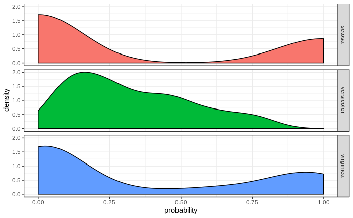

**Q. What do you learn from this plot?**

```r
caret::confusionMatrix(as.factor(pred_classes), iris[,5])
```

```
Confusion Matrix and Statistics

            Reference
Prediction   setosa versicolor virginica
  setosa         50          0         0
  versicolor      0         46         2
  virginica       0          4        48

Overall Statistics

               Accuracy : 0.96
                 95% CI : (0.915, 0.9852)
    No Information Rate : 0.3333
    P-Value [Acc > NIR] : < 2.2e-16

                  Kappa : 0.94
 Mcnemar's Test P-Value : NA

Statistics by Class:

                     Class: setosa Class: versicolor Class: virginica
Sensitivity                 1.0000            0.9200           0.9600
Specificity                 1.0000            0.9800           0.9600
Pos Pred Value              1.0000            0.9583           0.9231
Neg Pred Value              1.0000            0.9608           0.9796
Prevalence                  0.3333            0.3333           0.3333
Detection Rate              0.3333            0.3067           0.3200
Detection Prevalence        0.3333            0.3200           0.3467
Balanced Accuracy           1.0000            0.9500           0.9600
```

**Q. What does the confusion matrix tell us?**

**Q. Based on the above plots, would you say this is a good result?**